# Project 2: Data Mining, Classification, Prediction

SDS322E

# Mining, Classification, Prediction

## Tia Frederick

### Introduction

I used a dataset from Project 1, which is called data3. The dataset is a combination of the datasets “USArrests: Violent Crime Rates by US State” and “Anscombe: U.S. State Public-School Expenditures.” US Arressts contains statistics in arrests per 100,000 residents for assault, murder, and rape in each of the 50 U.S. states in 1973, and the variables are labeled as ‘Assault’, ‘Murder’, and ‘Rape’, respectively. The dataset also provides the percent of the population living in urban areas, labeled as ‘UrbanPop’. The Anscombe dataset contains statistics for the U.S. states plus Washington D.C. in 1970 for per-capita education expenditures in dollars (‘education’ variable), per-capita income (‘income’ variable), proportion under 18 years old per 1000 residents (‘young’ variable), and urban proportion per 1000 (‘urban’ variable). The USArrest dataset has 50 observations and 5 variables, and the Anscombe dataset has 51 observations and 5 variables, and the variable name for the states column is called “X1” for both datasets. The finalized dataset for data3 from Project 1 has 50 rows and 11 columns. The variables are: States, education, income, young, urban, Murder, Assault, Rape, UrbanPercent, Total_Arrests, and high_low_UrbanPercent. The variables, Total_Arrests and high_low_UrbanPercent, were mutated into data3 in Project1. “Total_Arrests” was generated by adding up the data in the crime columns. For the high_low_UrbanPercent variable, an urban percentage is categorized as high if it is greater than or equal to 60% and a low urban percentage is lower than 60%. One of my interesting findings from the previous project was that there were 33 states that are categorized has a high urban percentage and 17 states with a low urban percentage.

```r
library(tidyverse)
# read your datasets in here, e.g., with read_csv() if your
# dataset needs tidying, do so here any other code here


# write.csv( file='data3.csv')
data3 <- read_csv("data3.csv")
data3
```

```
## # A tibble: 50 x 12
##       X1 States education income young urban Murder Assault  Rape UrbanPercent
##    <dbl> <chr>      <dbl>  <dbl> <dbl> <dbl>  <dbl>   <dbl> <dbl>        <dbl>
##  1     1 Alaba…       112   2337  362.   584   13.2     236  21.2           58
##  2     2 Alaska       372   4146  440.   484   10       263  44.5           48
##  3     3 Arizo…       207   3027  388.   796    8.1     294  31             80
##  4     4 Arkan…       134   2322  352.   500    8.8     190  19.5           50
##  5     5 Calif…       273   3968  348.   909    9       276  40.6           91
##  6     6 Color…       192   3340  358.   785    7.9     204  38.7           78
##  7     7 Conne…       193   4256  341    774    3.3     110  11.1           77
##  8     8 Delaw…       248   3795  376.   722    5.9     238  15.8           72
##  9     9 Flori…       191   3191  336    805   15.4     335  31.9           80
## 10    10 Georg…       156   2781  371.   603   17.4     211  25.8           60
## # … with 40 more rows, and 2 more variables: Total_Arrests <dbl>,
## #   high_low_UrbanPercent <chr>
```

```r
data3 <- data3 %>% select(-1)
data3
```

```
## # A tibble: 50 x 11
##    States education income young urban Murder Assault  Rape UrbanPercent
##    <chr>      <dbl>  <dbl> <dbl> <dbl>  <dbl>   <dbl> <dbl>        <dbl>
##  1 Alaba…       112   2337  362.   584   13.2     236  21.2           58
##  2 Alaska       372   4146  440.   484   10       263  44.5           48
##  3 Arizo…       207   3027  388.   796    8.1     294  31             80
##  4 Arkan…       134   2322  352.   500    8.8     190  19.5           50
##  5 Calif…       273   3968  348.   909    9       276  40.6           91
##  6 Color…       192   3340  358.   785    7.9     204  38.7           78
##  7 Conne…       193   4256  341    774    3.3     110  11.1           77
##  8 Delaw…       248   3795  376.   722    5.9     238  15.8           72
##  9 Flori…       191   3191  336    805   15.4     335  31.9           80
## 10 Georg…       156   2781  371.   603   17.4     211  25.8           60
## # … with 40 more rows, and 2 more variables: Total_Arrests <dbl>,
## #   high_low_UrbanPercent <chr>
```

### Cluster Analysis

```r
library(cluster)

Data3 <- data3 %>% select(-1)
Data3 <- Data3 %>% select(-10)
Data3
```

```
## # A tibble: 50 x 9
##    education income young urban Murder Assault  Rape UrbanPercent Total_Arrests
##        <dbl>  <dbl> <dbl> <dbl>  <dbl>   <dbl> <dbl>        <dbl>         <dbl>
##  1       112   2337  362.   584   13.2     236  21.2           58          270.
##  2       372   4146  440.   484   10       263  44.5           48          318.
##  3       207   3027  388.   796    8.1     294  31             80          333.
##  4       134   2322  352.   500    8.8     190  19.5           50          218.
##  5       273   3968  348.   909    9       276  40.6           91          326.
##  6       192   3340  358.   785    7.9     204  38.7           78          251.
##  7       193   4256  341    774    3.3     110  11.1           77          124.
##  8       248   3795  376.   722    5.9     238  15.8           72          260.
##  9       191   3191  336    805   15.4     335  31.9           80          382.
## 10       156   2781  371.   603   17.4     211  25.8           60          254.
## # … with 40 more rows
```

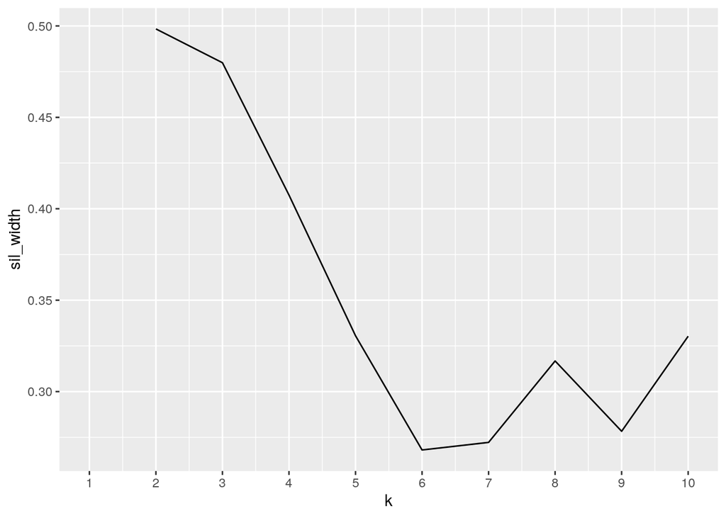

```r
sil_width <- vector()
for (i in 2:10) {
    kms <- kmeans(Data3, centers = i)
    sil <- silhouette(kms$cluster, dist(Data3))
    sil_width[i] <- mean(sil[, 3])
}
ggplot() + geom_line(aes(x = 1:10, y = sil_width)) + scale_x_continuous(name = "k",
    breaks = 1:10)
```

```r
data3_pam <- data3 %>% pam(k = 2)
data3_pam$silinfo$avg.width
```

```
## [1] 0.4983569
```

```r
data3_pam
```

```
## Medoids:
##      ID States education income young urban Murder Assault Rape UrbanPercent
## [1,] 12     NA       170   2668 367.7   541    2.6     120 14.2           54
## [2,] 35     NA       172   3509 354.5   753    7.3     120 21.4           75
##      Total_Arrests high_low_UrbanPercent
## [1,]         136.8                    NA
## [2,]         148.7                    NA
## Clustering vector:
##  [1] 1 2 1 1 2 2 2 2 2 1 2 1 2 2 2 2 1 1 1 2 2 2 2 1 2 1 2 2 2 2 1 2 1 1 2 1 2 2
## [39] 2 1 1 1 1 1 1 1 2 1 2 2
## Objective function:
##   build    swap
## 386.784 353.956
##
## Available components:
##  [1] "medoids"    "id.med"     "clustering" "objective"  "isolation"
##  [6] "clusinfo"   "silinfo"    "diss"       "call"       "data"
```

```r
# Clustering with three measurements

clust_dat <- data3 %>% dplyr::select(UrbanPercent, income, young)
set.seed(322)
pam1 <- clust_dat %>% pam(k = 2)
pam1
```

```
## Medoids:
##      ID UrbanPercent income young
## [1,] 34           44   2730 369.1
## [2,] 35           75   3509 354.5
## Clustering vector:
##  [1] 1 2 1 1 2 2 2 2 2 1 2 1 2 2 2 2 1 1 1 2 2 2 2 1 2 1 2 2 2 2 1 2 1 1 2 1 2 2
## [39] 2 1 1 1 1 1 1 1 2 1 2 2
## Objective function:
##    build     swap
## 281.6760 250.5995
##
## Available components:
##  [1] "medoids"    "id.med"     "clustering" "objective"  "isolation"
##  [6] "clusinfo"   "silinfo"    "diss"       "call"       "data"
```

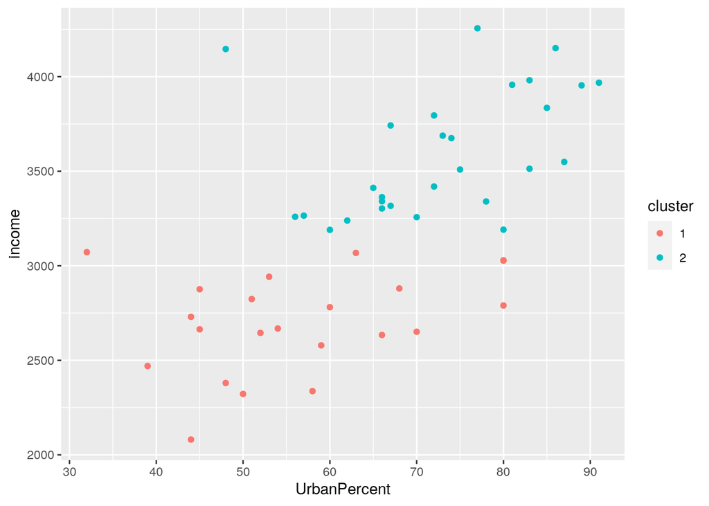

```r
pamclust <- clust_dat %>% mutate(cluster = as.factor(pam1$clustering))  #save the cluster solution in your dataset
pamclust %>% ggplot(aes(UrbanPercent, income, high_low_UrbanPercent,
    color = cluster)) + geom_point()  #visualize it
```

```r
pamclust %>% group_by(cluster) %>% summarize_if(is.numeric, mean,
    na.rm = T)
```

```
## # A tibble: 2 x 4
##   cluster UrbanPercent income young
##   <fct>          <dbl>  <dbl> <dbl>
## 1 1               56.4  2702.  366.
## 2 2               72.7  3593.  353.
```

```r
data3 %>% slice(pam1$id.med)
```

```
## # A tibble: 2 x 11
##   States education income young urban Murder Assault  Rape UrbanPercent
##   <chr>      <dbl>  <dbl> <dbl> <dbl>  <dbl>   <dbl> <dbl>        <dbl>
## 1 North…       177   2730  369.   443    0.8      45   7.3           44
## 2 Ohio         172   3509  354.   753    7.3     120  21.4           75
## # … with 2 more variables: Total_Arrests <dbl>, high_low_UrbanPercent <chr>
```

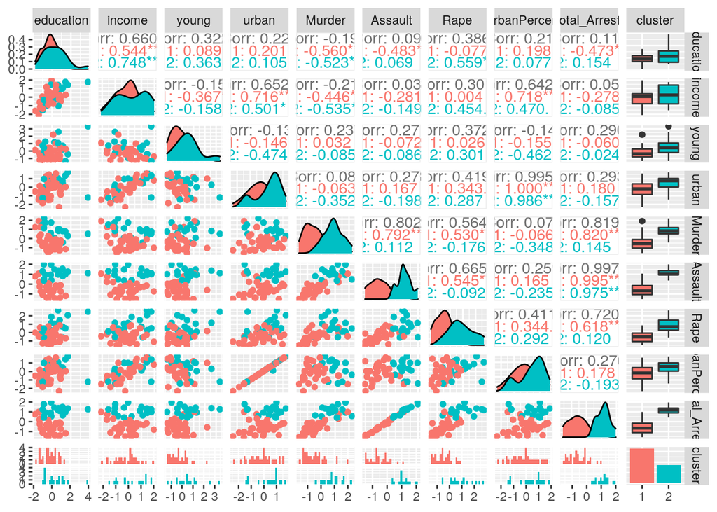

```r
# Clustering with all eight measurements

final <- data3 %>% select(-States) %>% select(-high_low_UrbanPercent) %>%
    scale %>% as.data.frame
pam2 <- final %>% pam(2)

# now that we ran PAM, save the cluster assignment in the
# dataset
final <- final %>% mutate(cluster = as.factor(pam2$clustering))

library(GGally)
ggpairs(final, aes(color = cluster))
```

### Dimensionality Reduction with PCA

```r
data31 <- data3 %>% select(-States)
data31 <- data31 %>% select(-high_low_UrbanPercent)
data31
```

```
## # A tibble: 50 x 9
##    education income young urban Murder Assault  Rape UrbanPercent Total_Arrests
##        <dbl>  <dbl> <dbl> <dbl>  <dbl>   <dbl> <dbl>        <dbl>         <dbl>
##  1       112   2337  362.   584   13.2     236  21.2           58          270.
##  2       372   4146  440.   484   10       263  44.5           48          318.
##  3       207   3027  388.   796    8.1     294  31             80          333.
##  4       134   2322  352.   500    8.8     190  19.5           50          218.
##  5       273   3968  348.   909    9       276  40.6           91          326.
##  6       192   3340  358.   785    7.9     204  38.7           78          251.
##  7       193   4256  341    774    3.3     110  11.1           77          124.
##  8       248   3795  376.   722    5.9     238  15.8           72          260.
##  9       191   3191  336    805   15.4     335  31.9           80          382.
## 10       156   2781  371.   603   17.4     211  25.8           60          254.
## # … with 40 more rows
```

```r
data31_nums <- data3 %>% select_if(is.numeric) %>% scale
rownames(data31_nums) <- data31$Name
data31_pca <- princomp(data31_nums)
names(data31_pca)
```

```
## [1] "sdev"     "loadings" "center"   "scale"    "n.obs"    "scores"   "call"
```

```r
# sdev contains the square root of the eigenvalue/variance
# explained loadings contains the eigenvectors/principal
# components scores contains the new variables (scores on
# principal components)

# Summarize results. summary() (with loadings=T) on the pca
# object gives you everything (except new PC scores)
summary(data31_pca, loadings = T)
```

```
## Importance of components:
##                           Comp.1    Comp.2    Comp.3     Comp.4     Comp.5
## Standard deviation     1.9478547 1.5827356 1.1690127 0.76370145 0.53356579
## Proportion of Variance 0.4301744 0.2840195 0.1549423 0.06612697 0.03227806
## Cumulative Proportion  0.4301744 0.7141939 0.8691361 0.93526311 0.96754116
##                            Comp.6     Comp.7       Comp.8 Comp.9
## Standard deviation     0.41556694 0.33098200 0.0635764417      0
## Proportion of Variance 0.01958003 0.01242053 0.0004582726      0
## Cumulative Proportion  0.98712120 0.99954173 1.0000000000      1
##
## Loadings:
##               Comp.1 Comp.2 Comp.3 Comp.4 Comp.5 Comp.6 Comp.7 Comp.8 Comp.9
## education      0.183  0.282  0.633  0.325  0.117         0.601
## income         0.215  0.504  0.139  0.335        -0.478 -0.580
## young          0.148 -0.229  0.592 -0.672  0.207 -0.187 -0.213
## urban          0.328  0.398 -0.271 -0.340                0.174 -0.711
## Murder         0.334 -0.394 -0.194        -0.140 -0.730  0.367
## Assault        0.432 -0.265         0.209  0.399  0.267 -0.146        -0.664
## Rape           0.437         0.171        -0.823  0.263 -0.156
## UrbanPercent   0.321  0.400 -0.280 -0.360                0.172  0.703
## Total_Arrests  0.445 -0.260         0.189  0.267  0.231 -0.129         0.744
```

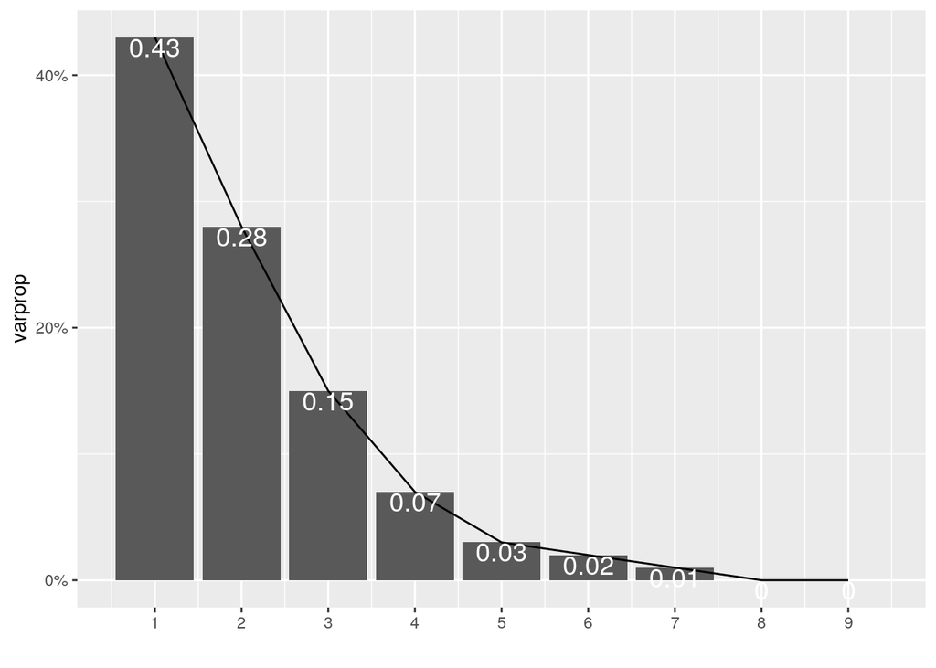

```r
# To decide how many PCs to keep, plot proportion of variance
# explained by each PC (from largest eigenvalue to smallest):
# a 'scree plot'


eigval <- data31_pca$sdev^2  #square to convert SDs to eigenvalues
varprop = round(eigval/sum(eigval), 2)  #proportion of var explained by each PC
ggplot() + geom_bar(aes(y = varprop, x = 1:9), stat = "identity") +
    xlab("") + geom_path(aes(y = varprop, x = 1:9)) + geom_text(aes(x = 1:9,
    y = varprop, label = round(varprop, 2)), vjust = 1, col = "white",
    size = 5) + scale_y_continuous(breaks = seq(0, 0.6, 0.2),
    labels = scales::percent) + scale_x_continuous(breaks = 1:10)
```

```r
# How many PCs to keep? Rules of thumb 1. Pick PCs until
# scree plot flattens (sometimes hard to tell where 'elbow'
# is) 2. Pick PCs until cumulative proportion of variance is
# > 80% 3. Pick PCs whose eigenvalues are greater than 1
# (Kaiser's rule)

round(cumsum(eigval)/sum(eigval), 2)  #cumulative proportion of variance
```

```
## Comp.1 Comp.2 Comp.3 Comp.4 Comp.5 Comp.6 Comp.7 Comp.8 Comp.9
##   0.43   0.71   0.87   0.94   0.97   0.99   1.00   1.00   1.00
```

```r
eigval  #eigenvalues
```

```
##      Comp.1      Comp.2      Comp.3      Comp.4      Comp.5      Comp.6
## 3.794137864 2.505052068 1.366590784 0.583239898 0.284692456 0.172695884
##      Comp.7      Comp.8      Comp.9
## 0.109549082 0.004041964 0.000000000
```

```r
# Interpret PCs: Look at loadings/eigenvectors to interpret
# components (bottom part of output)

summary(data31_pca, loadings = T)
```

```
## Importance of components:
##                           Comp.1    Comp.2    Comp.3     Comp.4     Comp.5
## Standard deviation     1.9478547 1.5827356 1.1690127 0.76370145 0.53356579
## Proportion of Variance 0.4301744 0.2840195 0.1549423 0.06612697 0.03227806
## Cumulative Proportion  0.4301744 0.7141939 0.8691361 0.93526311 0.96754116
##                            Comp.6     Comp.7       Comp.8 Comp.9
## Standard deviation     0.41556694 0.33098200 0.0635764417      0
## Proportion of Variance 0.01958003 0.01242053 0.0004582726      0
## Cumulative Proportion  0.98712120 0.99954173 1.0000000000      1
##
## Loadings:
##               Comp.1 Comp.2 Comp.3 Comp.4 Comp.5 Comp.6 Comp.7 Comp.8 Comp.9
## education      0.183  0.282  0.633  0.325  0.117         0.601
## income         0.215  0.504  0.139  0.335        -0.478 -0.580
## young          0.148 -0.229  0.592 -0.672  0.207 -0.187 -0.213
## urban          0.328  0.398 -0.271 -0.340                0.174 -0.711
## Murder         0.334 -0.394 -0.194        -0.140 -0.730  0.367
## Assault        0.432 -0.265         0.209  0.399  0.267 -0.146        -0.664
## Rape           0.437         0.171        -0.823  0.263 -0.156
## UrbanPercent   0.321  0.400 -0.280 -0.360                0.172  0.703
## Total_Arrests  0.445 -0.260         0.189  0.267  0.231 -0.129         0.744
```

```r
# Conducting PCA manually
eig1 <- data31 %>% cor %>% eigen
eig1
```

```
## eigen() decomposition
## $values
## [1]  3.871569e+00  2.556176e+00  1.394480e+00  5.951428e-01  2.905025e-01
## [6]  1.762203e-01  1.117848e-01  4.124453e-03 -1.112662e-17
##
## $vectors
##            [,1]        [,2]        [,3]        [,4]        [,5]        [,6]
##  [1,] 0.1826579 -0.28243408  0.63306544  0.32453429 -0.11665217 -0.07817385
##  [2,] 0.2148376 -0.50373831  0.13936373  0.33450580 -0.06343979  0.47771186
##  [3,] 0.1478466  0.22922231  0.59174616 -0.67238880 -0.20713004  0.18670581
##  [4,] 0.3280545 -0.39755646 -0.27111180 -0.33975206 -0.09163966 -0.03639032
##  [5,] 0.3341675  0.39383084 -0.19429865  0.07979791  0.14000117  0.73031794
##  [6,] 0.4323085  0.26535085 -0.08170953  0.20866898 -0.39911903 -0.26718007
##  [7,] 0.4374586  0.05103522  0.17082341 -0.01316942  0.82283589 -0.26347036
##  [8,] 0.3205743 -0.39999822 -0.27986690 -0.35996525 -0.06116373 -0.04527254
##  [9,] 0.4453157  0.26032234 -0.06485552  0.18864342 -0.26715305 -0.23082719
##             [,7]          [,8]          [,9]
##  [1,]  0.6007621  0.0117793988  0.000000e+00
##  [2,] -0.5800439  0.0095905248  5.603996e-16
##  [3,] -0.2134620  0.0006129199 -1.258522e-16
##  [4,]  0.1739905 -0.7109157897 -3.434886e-14
##  [5,]  0.3673184  0.0043944329 -3.468310e-02
##  [6,] -0.1458128  0.0119751628 -6.636212e-01
##  [7,] -0.1560991 -0.0163077420 -7.458491e-02
##  [8,]  0.1723055  0.7027469510  3.349823e-14
##  [9,] -0.1286660  0.0092572560  7.435328e-01
```

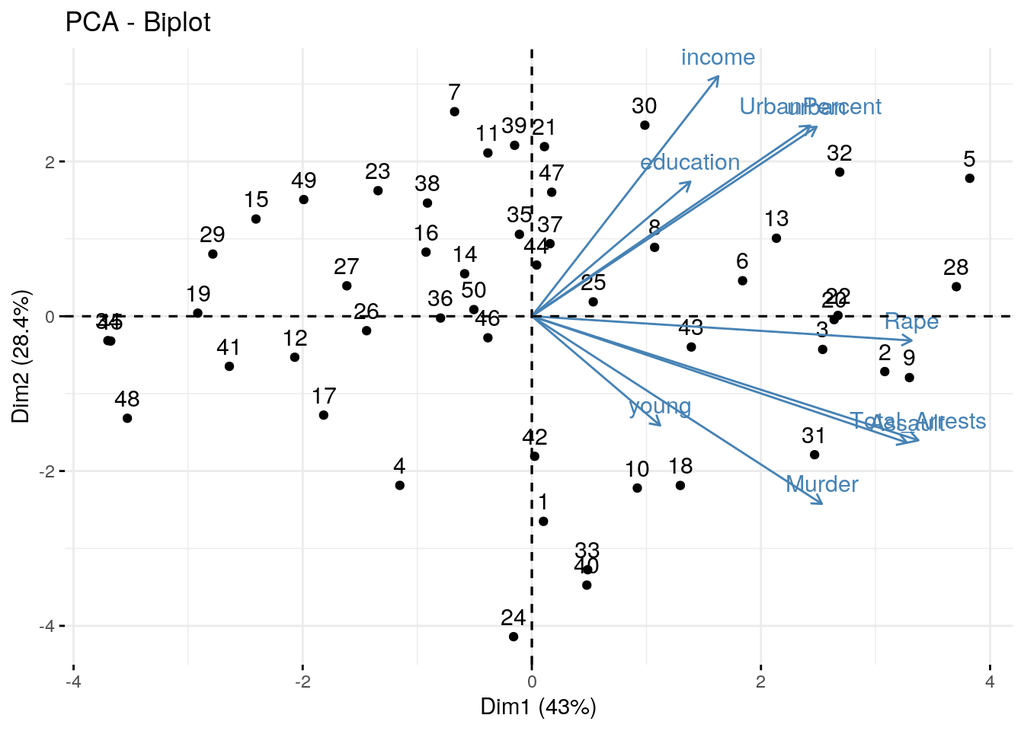

```r
# Plot of loadings (which vars contribute to which PCs).
# Better plots with factoextra
library(factoextra)
fviz_pca_biplot(data31_pca)
```

PC1 is the general strength axis: all loadings/coefs have similar sign and magnitude. The higher a state scores on PC1, all eight varaibles will be high. PC2 is an Income vs. Murder axis. Higher scores on PC2 mean high income and low Murder rate. Lower scores on PC2 mean the opposite: low income but high Murder rate. PC3 is an Education vs. UrbanPercent axis. Higher scores on PC3 mean high education and low UrbanPercent. Lower scores mean low education and high UrbanPercent. The total variance of the scaled data was 8.82, so total variance of PCs must be 8.82. The proportion of variance explained by PC1 is 0.4301744 and the proportion of variance explained by PC2 is 0.2840195. Therefore, the total variance of in the dataset explained by the PC1 is 3.794137864 and total variance explained by PC2 is 2.505052068.

### Linear Classifier

```r
# The response variable for binary classification,
# high_low_UrbanPercent, is coded as a factor type: 'high' or
# 'low.' I explicitly converted it to numeric so 'high' is 1
# and 'low' is 0.
data32 <- data3 %>% mutate(high_low_UrbanPercent = ifelse(high_low_UrbanPercent ==
    "high", 1, 0))
data32
```

```
## # A tibble: 50 x 11
##    States education income young urban Murder Assault  Rape UrbanPercent
##    <chr>      <dbl>  <dbl> <dbl> <dbl>  <dbl>   <dbl> <dbl>        <dbl>
##  1 Alaba…       112   2337  362.   584   13.2     236  21.2           58
##  2 Alaska       372   4146  440.   484   10       263  44.5           48
##  3 Arizo…       207   3027  388.   796    8.1     294  31             80
##  4 Arkan…       134   2322  352.   500    8.8     190  19.5           50
##  5 Calif…       273   3968  348.   909    9       276  40.6           91
##  6 Color…       192   3340  358.   785    7.9     204  38.7           78
##  7 Conne…       193   4256  341    774    3.3     110  11.1           77
##  8 Delaw…       248   3795  376.   722    5.9     238  15.8           72
##  9 Flori…       191   3191  336    805   15.4     335  31.9           80
## 10 Georg…       156   2781  371.   603   17.4     211  25.8           60
## # … with 40 more rows, and 2 more variables: Total_Arrests <dbl>,
## #   high_low_UrbanPercent <dbl>
```

```r
fit <- glm(high_low_UrbanPercent ~ income, data = data32, family = "binomial")
score <- predict(fit, type = "response")
class_diag(score, data32$high_low_UrbanPercent, positive = 1)
```

```
##          acc   sens   spec    ppv     f1     ba   auc
## Metrics 0.82 0.8788 0.7059 0.8529 0.8657 0.7923 0.852
```

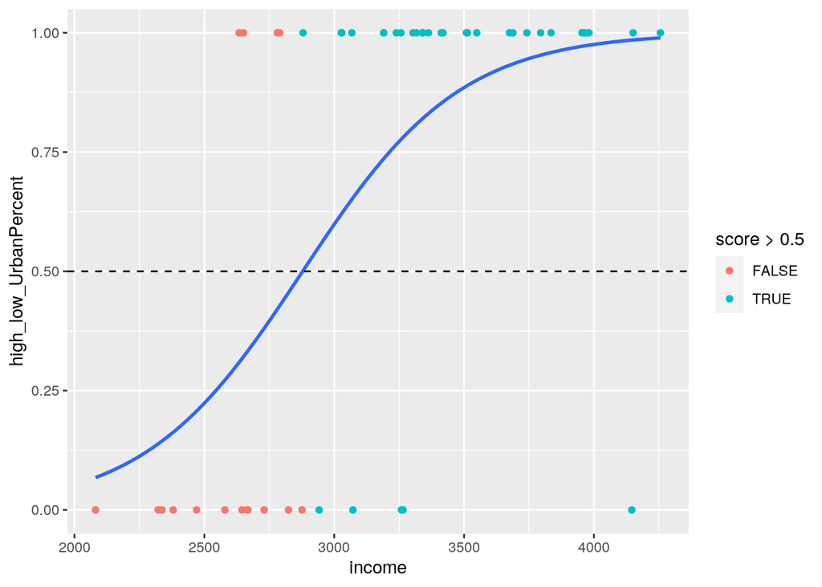

```r
# Predict a binary variable (response) from ALL of the rest
# of the numeric variables in the dataset. Predict
# high_low_UrbanPercent (high=1, low=0) from each of the
# numeric variables

data32 %>% mutate(score = score) %>% ggplot(aes(income, high_low_UrbanPercent)) +
    geom_point(aes(color = score > 0.5)) + geom_smooth(method = "glm",
    se = F, method.args = list(family = "binomial")) + ylim(0,
    1) + geom_hline(yintercept = 0.5, lty = 2)
```

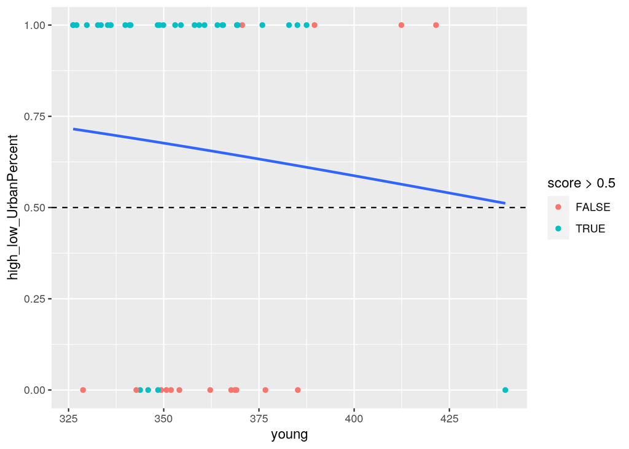

```r
data32 %>% mutate(score = score) %>% ggplot(aes(young, high_low_UrbanPercent)) +
    geom_point(aes(color = score > 0.5)) + geom_smooth(method = "glm",
    se = F, method.args = list(family = "binomial")) + ylim(0,
    1) + geom_hline(yintercept = 0.5, lty = 2)
```

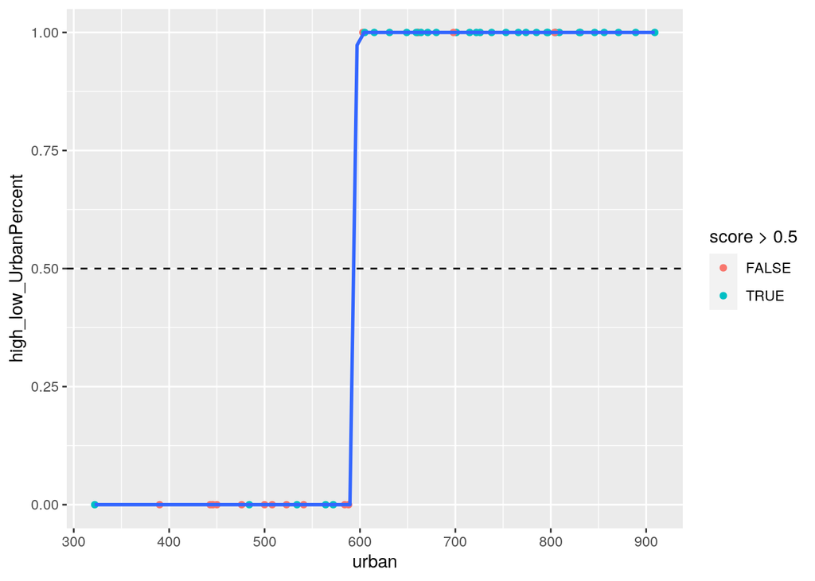

```r
data32 %>% mutate(score = score) %>% ggplot(aes(urban, high_low_UrbanPercent)) +
    geom_point(aes(color = score > 0.5)) + geom_smooth(method = "glm",
    se = F, method.args = list(family = "binomial")) + ylim(0,
    1) + geom_hline(yintercept = 0.5, lty = 2)
```

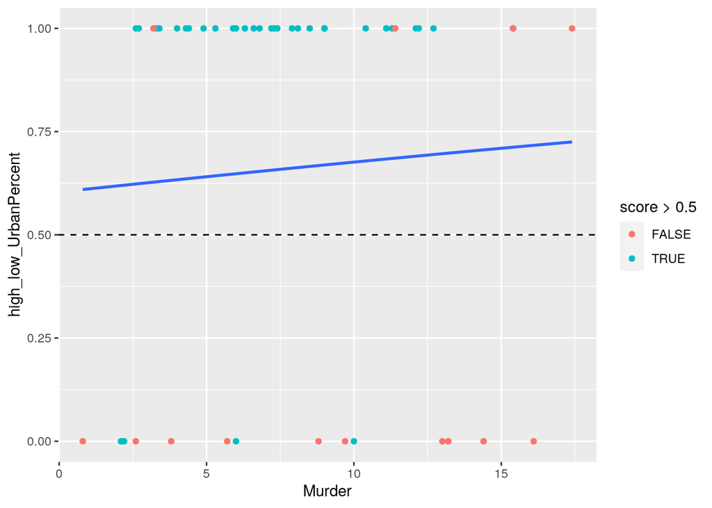

```r
data32 %>% mutate(score = score) %>% ggplot(aes(Murder, high_low_UrbanPercent)) +
    geom_point(aes(color = score > 0.5)) + geom_smooth(method = "glm",
    se = F, method.args = list(family = "binomial")) + ylim(0,
    1) + geom_hline(yintercept = 0.5, lty = 2)
```

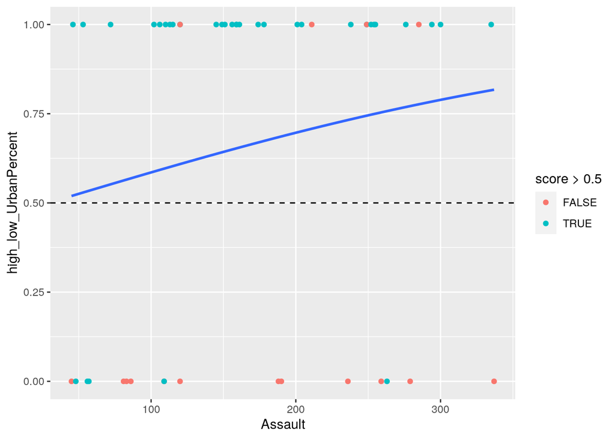

```r
data32 %>% mutate(score = score) %>% ggplot(aes(Assault, high_low_UrbanPercent)) +
    geom_point(aes(color = score > 0.5)) + geom_smooth(method = "glm",
    se = F, method.args = list(family = "binomial")) + ylim(0,
    1) + geom_hline(yintercept = 0.5, lty = 2)
```

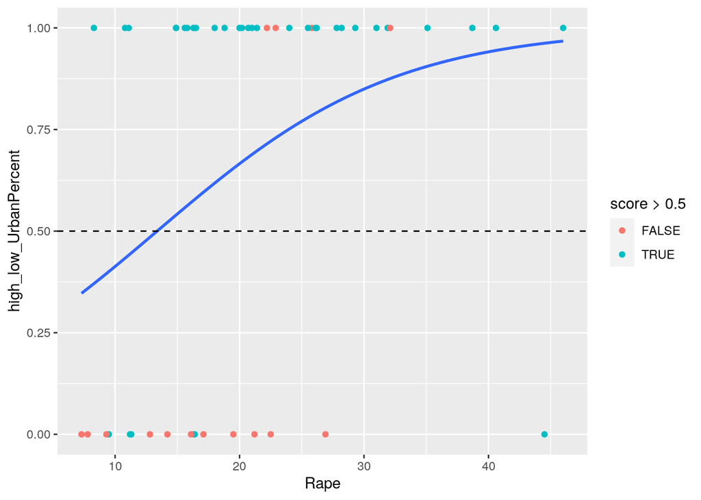

```r
data32 %>% mutate(score = score) %>% ggplot(aes(Rape, high_low_UrbanPercent)) +
    geom_point(aes(color = score > 0.5)) + geom_smooth(method = "glm",
    se = F, method.args = list(family = "binomial")) + ylim(0,
    1) + geom_hline(yintercept = 0.5, lty = 2)
```

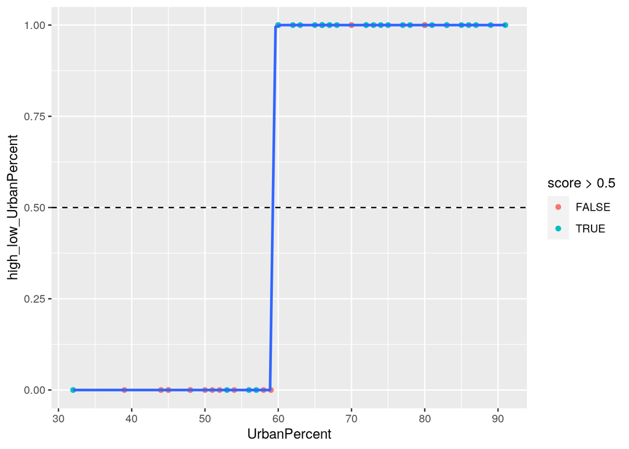

```r
data32 %>% mutate(score = score) %>% ggplot(aes(UrbanPercent,
    high_low_UrbanPercent)) + geom_point(aes(color = score >
    0.5)) + geom_smooth(method = "glm", se = F, method.args = list(family = "binomial")) +
    ylim(0, 1) + geom_hline(yintercept = 0.5, lty = 2)
```

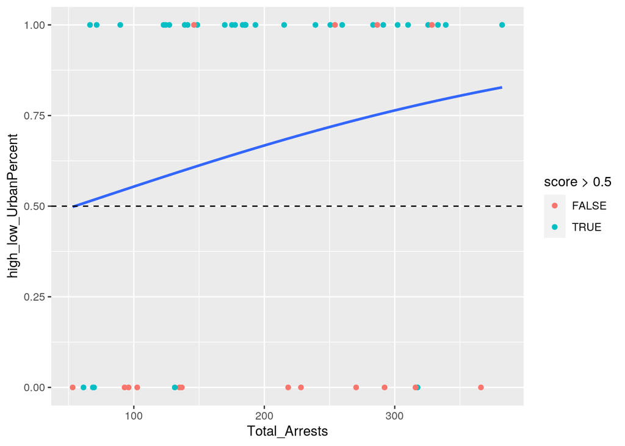

```r
data32 %>% mutate(score = score) %>% ggplot(aes(Total_Arrests,
    high_low_UrbanPercent)) + geom_point(aes(color = score >
    0.5)) + geom_smooth(method = "glm", se = F, method.args = list(family = "binomial")) +
    ylim(0, 1) + geom_hline(yintercept = 0.5, lty = 2)
```

```r
print("--------------------------------------------------------------------------------------")
```

```
## [1] "--------------------------------------------------------------------------------------"
```

```r
fit <- glm(high_low_UrbanPercent ~ income + young + urban + Assault +
    Murder + Rape + UrbanPercent + Total_Arrests, data = data32,
    family = "binomial")
probs <- predict(fit, type = "response")
score %>% round(3)
```

```
##     1     2     3     4     5     6     7     8     9    10    11    12    13
## 0.144 0.985 0.620 0.138 0.973 0.820 0.989 0.953 0.736 0.421 0.890 0.334 0.974
##    14    15    16    17    18    19    20    21    22    23    24    25    26
## 0.852 0.781 0.802 0.317 0.309 0.455 0.945 0.959 0.932 0.821 0.068 0.776 0.552
##    27    28    29    30    31    32    33    34    35    36    37    38    39
## 0.766 0.972 0.777 0.972 0.321 0.985 0.331 0.380 0.888 0.501 0.809 0.855 0.901
##    40    41    42    43    44    45    46    47    48    49    50
## 0.163 0.498 0.272 0.621 0.428 0.654 0.651 0.935 0.207 0.831 0.736
```

```r
class_diag(score, truth = data32$high_low_UrbanPercent, positive = 1)
```

```
##          acc   sens   spec    ppv     f1     ba   auc
## Metrics 0.82 0.8788 0.7059 0.8529 0.8657 0.7923 0.852
```

```r
print("----------------------------------------------------------")
```

```
## [1] "----------------------------------------------------------"
```

```r
table(truth = data32$high_low_UrbanPercent, prediction = probs >
    0.5)
```

```
##      prediction
## truth FALSE TRUE
##     0    17    0
##     1     0   33
```

```r
Data3 <- data32 %>% select(-1)
Data3
```

```
## # A tibble: 50 x 10
##    education income young urban Murder Assault  Rape UrbanPercent Total_Arrests
##        <dbl>  <dbl> <dbl> <dbl>  <dbl>   <dbl> <dbl>        <dbl>         <dbl>
##  1       112   2337  362.   584   13.2     236  21.2           58          270.
##  2       372   4146  440.   484   10       263  44.5           48          318.
##  3       207   3027  388.   796    8.1     294  31             80          333.
##  4       134   2322  352.   500    8.8     190  19.5           50          218.
##  5       273   3968  348.   909    9       276  40.6           91          326.
##  6       192   3340  358.   785    7.9     204  38.7           78          251.
##  7       193   4256  341    774    3.3     110  11.1           77          124.
##  8       248   3795  376.   722    5.9     238  15.8           72          260.
##  9       191   3191  336    805   15.4     335  31.9           80          382.
## 10       156   2781  371.   603   17.4     211  25.8           60          254.
## # … with 40 more rows, and 1 more variable: high_low_UrbanPercent <dbl>
```

```r
y <- Data3$high_low_UrbanPercent
y <- factor(y, levels = c("high", "low"))
x <- Data3$income


data33 <- Data3 %>% mutate(y = high_low_UrbanPercent)
data33$high_low_UrbanPercent <- NULL  #remove this variable for now
data33
```

```
## # A tibble: 50 x 10
##    education income young urban Murder Assault  Rape UrbanPercent Total_Arrests
##        <dbl>  <dbl> <dbl> <dbl>  <dbl>   <dbl> <dbl>        <dbl>         <dbl>
##  1       112   2337  362.   584   13.2     236  21.2           58          270.
##  2       372   4146  440.   484   10       263  44.5           48          318.
##  3       207   3027  388.   796    8.1     294  31             80          333.
##  4       134   2322  352.   500    8.8     190  19.5           50          218.
##  5       273   3968  348.   909    9       276  40.6           91          326.
##  6       192   3340  358.   785    7.9     204  38.7           78          251.
##  7       193   4256  341    774    3.3     110  11.1           77          124.
##  8       248   3795  376.   722    5.9     238  15.8           72          260.
##  9       191   3191  336    805   15.4     335  31.9           80          382.
## 10       156   2781  371.   603   17.4     211  25.8           60          254.
## # … with 40 more rows, and 1 more variable: y <dbl>
```

```r
fit <- glm(Data3$high_low_UrbanPercent ~ income, data = Data3,
    family = "binomial")  #fit model
prob <- predict(fit, type = "response")  #get predicted probabilities
prob
```

```
##          1          2          3          4          5          6          7
## 0.14431240 0.98473992 0.61973896 0.13832917 0.97293207 0.82015877 0.98932122
##          8          9         10         11         12         13         14
## 0.95316823 0.73644803 0.42060723 0.88955057 0.33364010 0.97403511 0.85247202
##         15         16         17         18         19         20         21
## 0.78089029 0.80151443 0.31704630 0.30926845 0.45538913 0.94474692 0.95870053
##         22         23         24         25         26         27         28
## 0.93205741 0.82064316 0.06776612 0.77635713 0.55206165 0.76591510 0.97196327
##         29         30         31         32         33         34         35
## 0.77749665 0.97169325 0.32133263 0.98498497 0.33072297 0.38037828 0.88825195
##         36         37         38         39         40         41         42
## 0.50129499 0.80873499 0.85534273 0.90065361 0.16266068 0.49800752 0.27202884
##         43         44         45         46         47         48         49
## 0.62128721 0.42783403 0.65393408 0.65095220 0.93471435 0.20706815 0.83104278
##         50
## 0.73580946
```

```r
class_diag(prob, data33$y, positive = 1)
```

```
##          acc   sens   spec    ppv     f1     ba   auc
## Metrics 0.82 0.8788 0.7059 0.8529 0.8657 0.7923 0.852
```

```r
set.seed(1234)
# split the dataset in two random parts
one <- data33 %>% sample_frac(0.5)
two <- data33 %>% anti_join(one)

## Train model on one part, test it on the other, get
## performance
fit <- glm(y ~ income, data = one, family = "binomial")
probs1 <- predict(fit, newdata = two, type = "response")
diags1 <- class_diag(probs1, two$y, positive = 1)

## Switch the sets around and repeat the process
fit <- glm(y ~ income, data = two, family = "binomial")
probs2 <- predict(fit, newdata = one, type = "response")
diags2 <- class_diag(probs2, one$y, positive = 1)
diags <- rbind(diags1, diags2)
diags
```

```
##           acc   sens   spec    ppv     f1     ba    auc
## Metrics  0.68 0.5882 0.8750 0.9091 0.7143 0.7316 0.7721
## Metrics1 0.80 1.0000 0.4444 0.7619 0.8649 0.7222 0.9583
```

```r
summarize_all(diags, mean)  #average diagnostics across all k folds
```

```
##    acc   sens   spec    ppv     f1     ba    auc
## 1 0.74 0.7941 0.6597 0.8355 0.7896 0.7269 0.8652
```

```r
set.seed(1234)
k = 10  #choose number of folds

data34 <- data33[sample(nrow(data33)), ]  #randomly order rows
folds <- cut(seq(1:nrow(data33)), breaks = k, labels = F)  #create folds

diags <- NULL
for (i in 1:k) {
    ## Create training and test sets
    train <- data34[folds != i, ]
    test <- data34[folds == i, ]
    truth <- test$y  ## Truth labels for fold i

    ## Train model on training set (all but fold i)
    fit <- glm(y ~ income, data = train, family = "binomial")
    ## Test model on test set (fold i)
    probs <- predict(fit, newdata = test, type = "response")
    ## Get diagnostics for fold i
    diags <- rbind(diags, class_diag(probs, truth, positive = 1))
}

summarize_all(diags, mean)  #average diagnostics across all k folds
```

```
##   acc    sens spec     ppv     f1  ba   auc
## 1 0.8 0.90167  NaN 0.83501 0.8442 NaN 0.925
```

The area under the AUC curve quantifies how well we are predicting overall. The AUC value after running the `class_diag` function is 0.852, which is a good value. I then performed k-fold CV on this same model. After running the `class_diag` function to get out-of-sample performance averaged across my k folds, my model predicts new observations per CV AUC very well since the AUC value came out to be 0.925. The goal of cross-validation is to test the model’s ability to make predictions on new data that was not used to estimate it. Since my model improved in CV, there is no sign of overfitting.

### Non-Parametric Classifier

```r
library(caret)

Data3
```

```
## # A tibble: 50 x 10
##    education income young urban Murder Assault  Rape UrbanPercent Total_Arrests
##        <dbl>  <dbl> <dbl> <dbl>  <dbl>   <dbl> <dbl>        <dbl>         <dbl>
##  1       112   2337  362.   584   13.2     236  21.2           58          270.
##  2       372   4146  440.   484   10       263  44.5           48          318.
##  3       207   3027  388.   796    8.1     294  31             80          333.
##  4       134   2322  352.   500    8.8     190  19.5           50          218.
##  5       273   3968  348.   909    9       276  40.6           91          326.
##  6       192   3340  358.   785    7.9     204  38.7           78          251.
##  7       193   4256  341    774    3.3     110  11.1           77          124.
##  8       248   3795  376.   722    5.9     238  15.8           72          260.
##  9       191   3191  336    805   15.4     335  31.9           80          382.
## 10       156   2781  371.   603   17.4     211  25.8           60          254.
## # … with 40 more rows, and 1 more variable: high_low_UrbanPercent <dbl>
```

```r
Data3 %>% select(1:9) %>% dist() %>% as.matrix %>% #euclidean distances among all datapoints
  as.data.frame %>% rownames_to_column %>%
  pivot_longer(-1) %>% left_join(select(rownames_to_column(Data3),rowname,high_low_UrbanPercent), by="rowname") %>%
  group_by(name) %>% slice_min(value, n=5) %>%#for each datapoint, grab the 5 closest points
  summarize(y_hat=mean(high_low_UrbanPercent))
```

```
## # A tibble: 50 x 2
##    name  y_hat
##    <chr> <dbl>
##  1 1       0
##  2 10      0.6
##  3 11      1
##  4 12      0
##  5 13      1
##  6 14      1
##  7 15      0.6
##  8 16      1
##  9 17      0
## 10 18      0.6
## # … with 40 more rows
```

```r
library(caret)
knn_fit <- knn3(factor(high_low_UrbanPercent==1,levels=c("TRUE","FALSE")) ~ education + income + young + urban + Assault + Murder + Rape + UrbanPercent + Total_Arrests, data=Data3, k=5)

y_hat_knn <- predict(knn_fit,Data3)

y_hat_knn
```

```
##       TRUE FALSE
##  [1,]  0.0   1.0
##  [2,]  0.8   0.2
##  [3,]  1.0   0.0
##  [4,]  0.0   1.0
##  [5,]  1.0   0.0
##  [6,]  1.0   0.0
##  [7,]  1.0   0.0
##  [8,]  1.0   0.0
##  [9,]  1.0   0.0
## [10,]  0.6   0.4
## [11,]  1.0   0.0
## [12,]  0.0   1.0
## [13,]  1.0   0.0
## [14,]  1.0   0.0
```

[output cut: 36 more lines]

```r
data.frame(y_hat_knn,names=rownames(Data3))%>% arrange(names) #The names are distinguished as numbers. Each number represents a State
```

```
##    TRUE. FALSE. names
## 1    0.0    1.0     1
## 2    0.6    0.4    10
## 3    1.0    0.0    11
## 4    0.0    1.0    12
## 5    1.0    0.0    13
## 6    1.0    0.0    14
## 7    0.6    0.4    15
## 8    1.0    0.0    16
## 9    0.0    1.0    17
## 10   0.6    0.4    18
## 11   0.0    1.0    19
## 12   0.8    0.2     2
## 13   1.0    0.0    20
## 14   1.0    0.0    21
```

[output cut: 20 more lines]

```r
table(truth= factor(Data3$high_low_UrbanPercent==1, levels=c("TRUE","FALSE")),
prediction= factor(y_hat_knn[,1]>.5, levels=c("TRUE","FALSE")))
```

```
##        prediction
## truth   TRUE FALSE
##   TRUE    33     0
##   FALSE    4    13
```

```r
class_diag(y_hat_knn[,1],Data3$high_low_UrbanPercent, positive=1)
```

```
##          acc sens   spec    ppv     f1     ba    auc
## Metrics 0.92    1 0.7647 0.8919 0.9429 0.8824 0.9795
```

```r
# cross-validation of np classifier here

# K-Fold CV with kNN

set.seed(1234)
k = 10  #choose number of folds

data <- data33[sample(nrow(data33)), ]  #randomly order rows
folds <- cut(seq(1:nrow(data33)), breaks = k, labels = F)  #create 10 folds

diags <- NULL
for (i in 1:k) {

    ## Create training and test sets
    train <- data33[folds != i, ]
    test <- data33[folds == i, ]
    truth <- test$y

    ## Train model on training set
    fit <- knn3(y ~ ., data = train)
    probs <- predict(fit, newdata = test)[, 2]

    ## Test model on test set (save all k results)
    diags <- rbind(diags, class_diag(probs, truth, positive = 1))
}

summarize_all(diags, mean)  #CV AUC a little worse with kNN
```

```
##    acc    sens spec     ppv      f1  ba   auc
## 1 0.88 0.96667  NaN 0.86834 0.90071 NaN 0.975
```

The CV AUC with kNN is 0.975, therefore the model is great at predicting new observations per CV AUC, and there are no signs of overfitting. It is also an improvement from CV AUC value with the linear model, which was 0.925.

### Regression/Numeric Prediction

```r
# regression model code here

fit <- lm(income ~ ., data = data33)  #predict income from all other variables
yhat <- predict(fit)  #predicted income

# Instead of classification diagnostics, calculate mean
# squared error (MSE)

mean((data33$income - yhat)^2)  #mean squared error (MSE)
```

```
## [1] 61056.9
```

```r
# cross-validation of regression model here

set.seed(1234)
k = 5  #choose number of folds
data <- data33[sample(nrow(data33)), ]  #randomly order rows
folds <- cut(seq(1:nrow(data33)), breaks = k, labels = F)  #create folds
diags <- NULL
for (i in 1:k) {
    train <- data[folds != i, ]
    test <- data[folds == i, ]
    ## Fit linear regression model to training set
    fit <- lm(income ~ ., data = train)
    ## Get predictions/y-hats on test set (fold i)
    yhat <- predict(fit, newdata = test)
    ## Compute prediction error (MSE) for fold i
    diags <- mean((test$income - yhat)^2)
}
mean(diags)
```

```
## [1] 68783.77
```

First, I predicted income from all the other variables, and instead of classification diagnostics, I calculated the mean squared error (MSE). The MSE is higher in CV, which is not good (means overfitting).

### Python

```r
library(reticulate)
use_python("/usr/bin/python3")


print(py$data_py)
```

[output not shown]

```python
print(r.data33.head())
```

```
##    education  income  young  urban ...   Rape  UrbanPercent  Total_Arrests    y
## 0      112.0  2337.0  362.2  584.0 ...   21.2          58.0          270.4  0.0
## 1      372.0  4146.0  439.7  484.0 ...   44.5          48.0          317.5  0.0
## 2      207.0  3027.0  387.5  796.0 ...   31.0          80.0          333.1  1.0
## 3      134.0  2322.0  351.9  500.0 ...   19.5          50.0          218.3  0.0
## 4      273.0  3968.0  348.4  909.0 ...   40.6          91.0          325.6  1.0
##
## [5 rows x 10 columns]
```

```python
data_py = r.data33
```